# drug_trial_neural_network__model

### We train the model by calling the fit() function on:

```
x=> input data,
y=> the labels or target data,
batch_size=> number of samples included in one batch for each iteration of neural network processing,
epochs=>number of times the model is going to train before it completes the training process,
shuffle=>remove any order on the datasets before training begins,
verbose=> enable output messages
validation_split=> splits a portion of the training data to create a validation dataset during train.This happens before the training set is shuffled.
```

```python
ann_model.fit(x=scaled_train_samples, y=train_labels, validation_split=0.1, batch_size=10, epochs=10, shuffle=True, verbose=2)
```

```
189/189 - 2s - loss: 0.7159 - accuracy: 0.4344 - val_loss: 0.6978 - val_accuracy: 0.4190 - 2s/epoch - 10ms/step
189/189 - 0s - loss: 0.6844 - accuracy: 0.5661 - val_loss: 0.6693 - val_accuracy: 0.6905 - 427ms/epoch - 2ms/step
189/189 - 0s - loss: 0.6485 - accuracy: 0.7386 - val_loss: 0.6332 - val_accuracy: 0.7810 - 405ms/epoch - 2ms/step
189/189 - 0s - loss: 0.6166 - accuracy: 0.7720 - val_loss: 0.6041 - val_accuracy: 0.8000 - 441ms/epoch - 2ms/step
189/189 - 0s - loss: 0.5871 - accuracy: 0.7915 - val_loss: 0.5751 - val_accuracy: 0.8190 - 456ms/epoch - 2ms/step
189/189 - 0s - loss: 0.5574 - accuracy: 0.8095 - val_loss: 0.5454 - val_accuracy: 0.8333 - 464ms/epoch - 2ms/step
189/189 - 0s - loss: 0.5281 - accuracy: 0.8317 - val_loss: 0.5165 - val_accuracy: 0.8381 - 439ms/epoch - 2ms/step
189/189 - 0s - loss: 0.5000 - accuracy: 0.8418 - val_loss: 0.4895 - val_accuracy: 0.8571 - 434ms/epoch - 2ms/step
189/189 - 0s - loss: 0.4733 - accuracy: 0.8503 - val_loss: 0.4637 - val_accuracy: 0.8762 - 438ms/epoch - 2ms/step
189/189 - 0s - loss: 0.4488 - accuracy: 0.8656 - val_loss: 0.4405 - val_accuracy: 0.8810 - 493ms/epoch - 3ms/step
```

```
<keras.callbacks.History at 0x21c7d55ceb0>
```

### Create a test dataset in order to use it inference how well the model would perform on a new dataset other than the validation data. Let's generate the tests datasets, in the same way, we generated the training dataset.

```python
test_samples = []
test_labels = []
```

```python
"""From the estimation above, we are going to generate a dummy dataset, the first for loop generates the 5% of particpants
from both categories of under 65 years and over 65 years."""

for i in range(50):
    """generate the approxmate 5% of participants under 65 years who exeprienced side effects (labeled 1)"""

    under_65 = randint(13,64)
    test_samples.append(under_65)
    test_labels.append(1)

    """generate the approxmate 5% of participants over 65 years who exeprienced no side effects (labeled 0)"""

    under_65 = randint(65,100)
    test_samples.append(under_65)
    test_labels.append(0)

print(len(test_samples))
print(len(test_labels))

for i in range(1000):
    """generate the approxmate 95% of participants under 65 years who exeprienced no side effects (labeled 0)"""

    random_younger = randint(13,64)
    test_samples.append(random_younger)
    test_labels.append(0)
    """generate the approxmate 95% of participants over 65 years who exeprienced side effects (labeled 1)"""

    random_older = randint(65,100)
    test_samples.append(random_older)
    test_labels.append(1)
print(len(test_samples))
print(len(test_labels))
```

```
100
100
2100
2100
```

```python
test_samples = np.array(test_samples)
test_labels = np.array(test_labels)
test_labels, test_samples = shuffle(test_labels, test_samples)
```

```python
scaled_test_samples = scaler.fit_transform(test_samples.reshape(-1,1))
```

## Now, we use the created model to predict on the test datasets by calling the predict() function on our trained model.

```python
predictions = ann_model.predict(x=scaled_test_samples, batch_size=10, verbose=0)
```

```python
for i in predictions:
    print(i)
```

```
[0.35783187 0.64216816]
[0.3223949 0.6776051]
[0.3223949 0.6776051]
[0.33988938 0.66011065]
[0.22850199 0.7714981 ]
[0.71788895 0.282111  ]
[0.19142014 0.80857986]
[0.44292834 0.55707157]
[0.3669586  0.63304144]
[0.6713817  0.32861832]
[0.5993402  0.40065983]
[0.7330704  0.26692963]
[0.33108377 0.6689163 ]
[0.16723247 0.83276755]
[0.265166 0.734834]
[0.25754097 0.742459  ]
[0.33988938 0.66011065]
[0.5511247 0.4488753]
[0.47233197 0.527668  ]
[0.22161332 0.7783867 ]
[0.17053168 0.8294683 ]
[0.18074082 0.8192592 ]
[0.5993402  0.40065983]
[0.17053168 0.8294683 ]
[0.54133433 0.4586656 ]
[0.73432136 0.26567867]
[0.3053843  0.69461566]
[0.5216653 0.4783347]
[0.56087554 0.43912452]
[0.265166 0.734834]
[0.73432136 0.26567867]
[0.7314079  0.26859203]
[0.48218626 0.51781374]
[0.7343286  0.26567143]
[0.3053843  0.69461566]
[0.22850199 0.7714981 ]
[0.67919934 0.32080072]
[0.21487449 0.78512555]
[0.22161332 0.7783867 ]
[0.27293378 0.7270662 ]
```

[output cut: 2045 more lines]

```
[0.265166 0.734834]
[0.5315121  0.46848792]
[0.65468955 0.3453104 ]
[0.39489397 0.60510606]
[0.17728584 0.8227142 ]
[0.25006068 0.7499393 ]
[0.49205443 0.50794554]
[0.265166 0.734834]
[0.7322399  0.26776004]
[0.71397144 0.2860286 ]
[0.33988938 0.66011065]
[0.22161332 0.7783867 ]
[0.22161332 0.7783867 ]
[0.18424807 0.8157519 ]
[0.5511247 0.4488753]
```

#### To get the most probable predication from the test dataset, we can take the index of the sample with the highest probability as follows:

```python
rounded_predictions = np.argmax(predictions, axis=-1)
```

```python
predicted_results = []
for i in rounded_predictions:
    predicted_results.append(i)
print(predicted_results)
```

```
[1, 1, 1, 1, 1, 0, 1, 1, 1, 0, 0, 0, 1, 1, 1, 1, 1, 0, 1, 1, 1, 1, 0, 1, 0, 0, 1, 0, 0, 1, 0, 0, 1, 0, 1, 1, 0, 1, 1, 1, 0, 1, 1, 1, 1, 1, 1, 1, 1, 0, 1, 1, 1, 0, 0, 1, 0, 0, 0, 1, 0, 1, 1, 1, 0, 0, 1, 1, 0, 1, 0, 0, 1, 1, 1, 0, 1, 0, 1, 1, 0, 1, 0, 0, 1, 1, 0, 0, 1, 1, 1, 1, 1, 0, 0, 0, 1, 1, 1, 1,…
```

###### From the predictions above, a 1 shows a higher probability of experiencing side effects, while a 0(zero) shows probability of not exeperiencing side effects.

### To assess how well the model performed on the test data, we can visualize the model's prediction accuracy through a confusion matrix.

```python
%matplotlib inline
from sklearn.metrics import confusion_matrix, accuracy_score
import itertools
import matplotlib.pyplot as plt
```

#### We pass the test labels as the truth/actual values and the predictions to the sklearn confusion matrix function.

```python
cm = confusion_matrix(y_true=test_labels, y_pred=rounded_predictions)
```

```python
"""Function source: sklearn website"""

def plot_confusion_matrix(cm, classes, normalize=False, title="Confusion matrix", cmap=plt.cm.Reds):
    """
    This fuctions prints and plots the Confusion matrix.
    Normalization can be applied be setting `normalize=True`
    """
    plt.imshow(cm, interpolation='nearest', cmap=cmap)
    plt.title(title)
    plt.colorbar()
    tick_marks = np.arange(len(classes))
    plt.xticks(tick_marks, classes, rotation=45)
    plt.yticks(tick_marks, classes)

    if normalize:
        cm = cm.astype('float') / cm.sum(axis=1)[:, np.newaxis]
        print("Normailzed Confusion Matrix")
    else:
        print("Confusion matrix, without normalization")
    print(cm)

    thresh = cm.max() /2.
    for i, j in itertools.product(range(cm.shape[0]), range(cm.shape[1])):
        plt.text(j , i, cm[i, j], horizontalalignment='center', color='white' if cm[i, j] > thresh else "black")
    plt.tight_layout()
    plt.ylabel("True label")
    plt.xlabel("Predicted label")
```

```
Confusion matrix, without normalization
[[ 826  224]
 [  46 1004]]
The accuracy score of the model: 0.8714285714285714
```

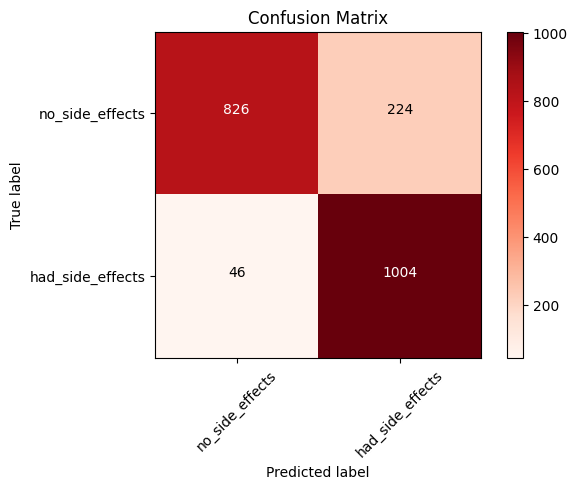

```python
cm_plot_labels = ["no_side_effects", "had_side_effects"]
plot_confusion_matrix(cm=cm, classes=cm_plot_labels, title="Confusion Matrix")

print(f"The accuracy score of the model: {accuracy_score(test_labels, rounded_predictions)}")
```

###### From the confusion matrix above, reading the diagonal from the top_left -- bottom_right, these are the true predictions which by simple calculations adds up to approxiamate 87.1% accuracy, which is not too off the 95% mark of our training data set.

#### Save and load the model. We use the model.save() function. From this, we can easily recreate the model from its architecture and can resume training from the point at which we left off.

### For comparison purposes, let's have a look at the summary, the weight and optimizer of the original model before saving it up on the disk from where we will load it up

###### The model summary

```python
ann_model.summary()
```

```
Model: "sequential"
_________________________________________________________________
 Layer (type)                Output Shape              Param #
=================================================================
 dense (Dense)               (None, 18)                36

 dense_1 (Dense)             (None, 36)                684

 dense_2 (Dense)             (None, 2)                 74

=================================================================
Total params: 794
Trainable params: 794
Non-trainable params: 0
_________________________________________________________________
```

###### The model weights

```python
ann_model.get_weights()
```

[output not shown]

[output cut: 214 more lines]

```
        [ 0.33814785,  0.21690306],
        [ 0.0102638 , -0.27941144],
        [-0.18358667,  0.2652848 ],
        [ 0.1665853 , -0.03708866],
        [ 0.11816686,  0.51077116],
        [ 0.13027085, -0.14487582],
        [-0.27920246, -0.07675743],
        [ 0.32454875, -0.40875694],
        [ 0.4808878 , -0.48154673],
        [ 0.28001955, -0.48455513],
        [ 0.25987843,  0.05550242],
        [ 0.11689958,  0.16720316],
        [ 0.0846348 ,  0.30832005],
        [-0.07172305,  0.02348405]], dtype=float32),
 array([ 0.04300566, -0.04300565], dtype=float32)]
```

###### The model optimizer

```python
ann_model.optimizer
```

```
<keras.optimizers.adam.Adam at 0x21c7d55cfd0>
```

# Saving the model

```python
"""confirm the file doesn't already exists, and save if not"""
import os.path
if os.path.isfile('models/drug_trial_ann_model.h5') is False:
    ann_model.save('models/drug_trial_ann_model.h5')
```

#### Now, we can load the saved model and compare it's architecture and different parameters with the original model

```python
from tensorflow.keras.models import load_model
load_stored_model = load_model('models/drug_trial_ann_model.h5')
```

```python
load_stored_model.summary()
```

```
Model: "sequential_1"
_________________________________________________________________
 Layer (type)                Output Shape              Param #
=================================================================
 dense_3 (Dense)             (None, 18)                36

 dense_4 (Dense)             (None, 36)                684

 dense_5 (Dense)             (None, 2)                 74

=================================================================
Total params: 794
Trainable params: 794
Non-trainable params: 0
_________________________________________________________________
```

```python
load_stored_model.get_weights()
```

[output not shown]

[output cut: 142 more lines]

```
        [-0.20023218, -0.14369352],
        [ 0.3453266 , -0.46266356],
        [ 0.12569895,  0.1589774 ],
        [-0.12540138, -0.06284091],
        [ 0.26115295,  0.01781683],
        [-0.00256279, -0.48762217],
        [-0.3754264 , -0.011254  ],
        [-0.18311316,  0.39941376],
        [-0.15571608, -0.03385833],
        [-0.03816602, -0.25023878],
        [-0.01668704,  0.3452631 ],
        [-0.32128155, -0.25667772],
        [ 0.4962499 , -0.55632395],
        [ 0.04036982,  0.42580456]], dtype=float32),
 array([ 0.08422312, -0.08422313], dtype=float32)]
```

```python
load_stored_model.optimizer
```

```
<keras.optimizers.adam.Adam at 0x21c03a9a5f0>
```